# Change in the US Treasury Yield Curve over time

Aditi Lapasia, Diego Alfaro Legonia, Edgar Pon, Ivy Liu, Teen Ho Nicholas Ching, Roberto Keaney, Susan Wang

# 1 Yield Curve Inversion

Every so often, we hear warnings from commentators on the “inverted yield curve” and its predictive power with respect to recessions. An explainer what a [inverted yield curve is can be found here](https://www.reuters.com/article/us-usa-economy-yieldcurve-explainer/explainer-what-is-an-inverted-yield-curve-idUSKBN1O50GA). If you’d rather listen to something, here is a great podcast from [NPR on yield curve indicators](https://www.podbean.com/media/share/dir-4zgj9-6aefd11)

In addition, many articles and commentators think that, e.g., [*Yield curve inversion is viewed as a harbinger of recession*](https://www.bloomberg.com/news/articles/2019-08-14/u-k-yield-curve-inverts-for-first-time-since-financial-crisis). One can always doubt whether inversions are truly a harbinger of recessions, and [use the attached parable on yield curve inversions](https://twitter.com/5_min_macro/status/1161627360946511873).

In our case we will look at US data and use the [FRED database](https://fred.stlouisfed.org/) to download historical yield curve rates, and plot the yield curves since 1999 to see when the yield curves flatten. If you want to know more, a very nice article that explains the [yield curve is and its inversion can be found here](https://fredblog.stlouisfed.org/2018/10/the-data-behind-the-fear-of-yield-curve-inversions/).

First, we will load the yield curve data file that contains data on the yield curve since 1960-01-01.

```r
yield_curve <- read_csv(here::here("data", "yield_curve.csv"))

glimpse(yield_curve)
```

```
## Rows: 6,884
## Columns: 5
## $ date      <date> 1960-01-01, 1960-02-01, 1960-03-01, 1960-04-01, 1960-05-01,~
## $ series_id <chr> "TB3MS", "TB3MS", "TB3MS", "TB3MS", "TB3MS", "TB3MS", "TB3MS~
## $ value     <dbl> 4.35, 3.96, 3.31, 3.23, 3.29, 2.46, 2.30, 2.30, 2.48, 2.30, ~
## $ maturity  <chr> "3m", "3m", "3m", "3m", "3m", "3m", "3m", "3m", "3m", "3m", ~
## $ duration  <chr> "3-Month Treasury Bill", "3-Month Treasury Bill", "3-Month T~
```

```r
#skimr::skim(yield_curve$duration)

yield_curve_table <- yield_curve %>%
                     mutate(duration = factor(duration, levels= c("3-Month Treasury Bill", "6-Month Treasury Bill", "1-Year Treasury Rate","2-Year Treasury Rate", "3-Year Treasury Rate", "5-Year Treasury Rate", "7-Year Treasury Rate", "10-Year Treasury Rate","20-Year Treasury Rate", "30-Year Treasury Rate")),
                            maturity = factor(maturity, levels= c("3m", "6m", "1y", "2y","3y","5y","7y","10y","20y","30y")))

yield_curve_table
```

```
## # A tibble: 6,884 x 5
##    date       series_id value maturity duration
##    <date>     <chr>     <dbl> <fct>    <fct>
##  1 1960-01-01 TB3MS      4.35 3m       3-Month Treasury Bill
##  2 1960-02-01 TB3MS      3.96 3m       3-Month Treasury Bill
##  3 1960-03-01 TB3MS      3.31 3m       3-Month Treasury Bill
##  4 1960-04-01 TB3MS      3.23 3m       3-Month Treasury Bill
##  5 1960-05-01 TB3MS      3.29 3m       3-Month Treasury Bill
##  6 1960-06-01 TB3MS      2.46 3m       3-Month Treasury Bill
##  7 1960-07-01 TB3MS      2.3  3m       3-Month Treasury Bill
##  8 1960-08-01 TB3MS      2.3  3m       3-Month Treasury Bill
##  9 1960-09-01 TB3MS      2.48 3m       3-Month Treasury Bill
## 10 1960-10-01 TB3MS      2.3  3m       3-Month Treasury Bill
## # ... with 6,874 more rows
```

```r
yield_curve_table_1 <- yield_curve_table %>%
                       select("date", "value", "duration") %>%
                       filter(duration %in% c("3-Month Treasury Bill","10-Year Treasury Rate")) %>%
                       pivot_wider(names_from = duration , values_from = value)

colnames(yield_curve_table_1) = c("date", "three_month", "ten_year" )

yield_curve_table_1
```

```
## # A tibble: 740 x 3
##    date       three_month ten_year
##    <date>           <dbl>    <dbl>
##  1 1960-01-01        4.35     4.72
##  2 1960-02-01        3.96     4.49
##  3 1960-03-01        3.31     4.25
##  4 1960-04-01        3.23     4.28
##  5 1960-05-01        3.29     4.35
##  6 1960-06-01        2.46     4.15
##  7 1960-07-01        2.3      3.9
##  8 1960-08-01        2.3      3.8
##  9 1960-09-01        2.48     3.8
## 10 1960-10-01        2.3      3.89
## # ... with 730 more rows
```

```r
yield_curve_table_2 <- yield_curve_table_1 %>%
                       group_by(date) %>%
                       mutate(difference = ten_year-three_month,
                              up = ifelse(difference>0, difference,0),
                              down = ifelse(difference<0, difference,0),
                              color_id = if_else(difference>0,"steelblue1","tomato2"))

yield_curve_table_2
```

```
## # A tibble: 740 x 7
## # Groups:   date [740]
##    date       three_month ten_year difference    up  down color_id
##    <date>           <dbl>    <dbl>      <dbl> <dbl> <dbl> <chr>
##  1 1960-01-01        4.35     4.72       0.37  0.37     0 steelblue1
##  2 1960-02-01        3.96     4.49       0.53  0.53     0 steelblue1
##  3 1960-03-01        3.31     4.25       0.94  0.94     0 steelblue1
##  4 1960-04-01        3.23     4.28       1.05  1.05     0 steelblue1
##  5 1960-05-01        3.29     4.35       1.06  1.06     0 steelblue1
##  6 1960-06-01        2.46     4.15       1.69  1.69     0 steelblue1
##  7 1960-07-01        2.3      3.9        1.6   1.6      0 steelblue1
##  8 1960-08-01        2.3      3.8        1.5   1.5      0 steelblue1
##  9 1960-09-01        2.48     3.8        1.32  1.32     0 steelblue1
## 10 1960-10-01        2.3      3.89       1.59  1.59     0 steelblue1
## # ... with 730 more rows
```

## 1.1 Plotting the yield curve

### 1.1.1 US Treasury Yields by duration since 1960

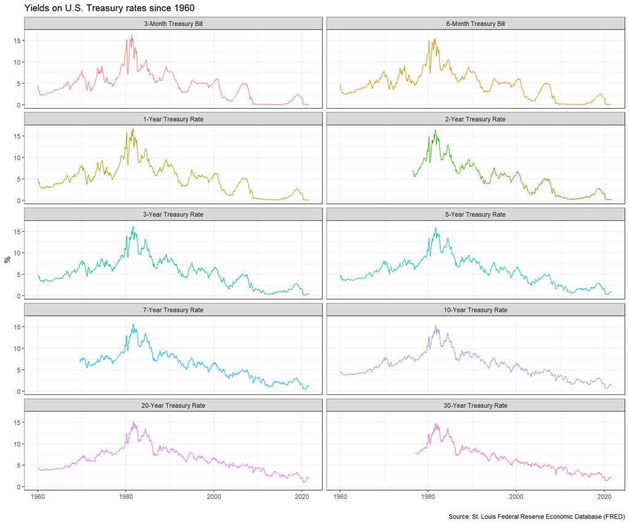

```r
ggplot(yield_curve_table, aes(x=date, y=value, color= duration)) +
  geom_line()+
  facet_wrap(~duration, ncol = 2) +
  theme_bw() +
  theme(legend.position = "none") +
  labs(title = "Yields on U.S. Treasury rates since 1960",
                 x ="",
                 y = "%",
                 caption = "Source: St. Louis Federal Reserve Economic Database (FRED)")+
  NULL
```

**Comment:**

During the early 1990s, the economy was still in recession and the Fed decided to increase rates. However, as inflation decreased, the Fed lowered interest rates (as shown in graphs) and the US economy experienced growth until the late 1990s. During the late 1990s and early 2000s, the US experienced a deterioration in its economy that forced the Fed to lower rates further in order to stimulate growth. Finally, after the 2008-2009 Financial Crisis, the Fed started to use another policy: Quantitative Easing. Via this new policy, the Fed would not only stimulate the economy through short term rates, but also in long term rates via purchasing of long-term bonds.

### 1.1.2 Monthly yields on US rates by duration since 1999 on a year-by-year basis

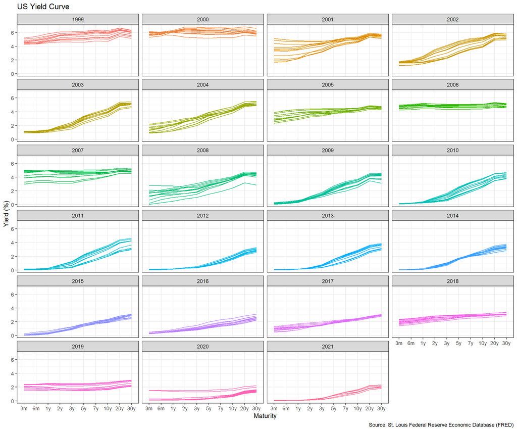

```r
yield_curve_table_3 <- yield_curve_table %>%
                       mutate(year = factor(year(date))) %>%
                       filter(date>='1999-01-01')

ggplot(yield_curve_table_3, aes(x= maturity, y= value, group = date, color= year))+
geom_path() +
facet_wrap(~year, ncol= 4)+
theme_bw() +
theme(legend.position = "none") +
labs(title = "US Yield Curve",
      x ="Maturity",
      y = "Yield (%)",
      caption = "Source: St. Louis Federal Reserve Economic Database (FRED)")+
  NULL
```

**Comment:**

Detailed graphs provide us with a better insight of how yield curves inverted between 12-24 month before recessions. For instance, during 2000, the graph shows an inversion in the yield curve 1 year before the 2001 crisis. Furthermore, before the 2008 crisis, the yield curve flattened in 2006 and 2007. Finally, in 2019 the yield curve flattened. However, it cannot be related to the 2020 crisis, which was caused by COVID 19 pandemic global restrictions.

### 1.1.3 3-month and 10-year yields since 1999

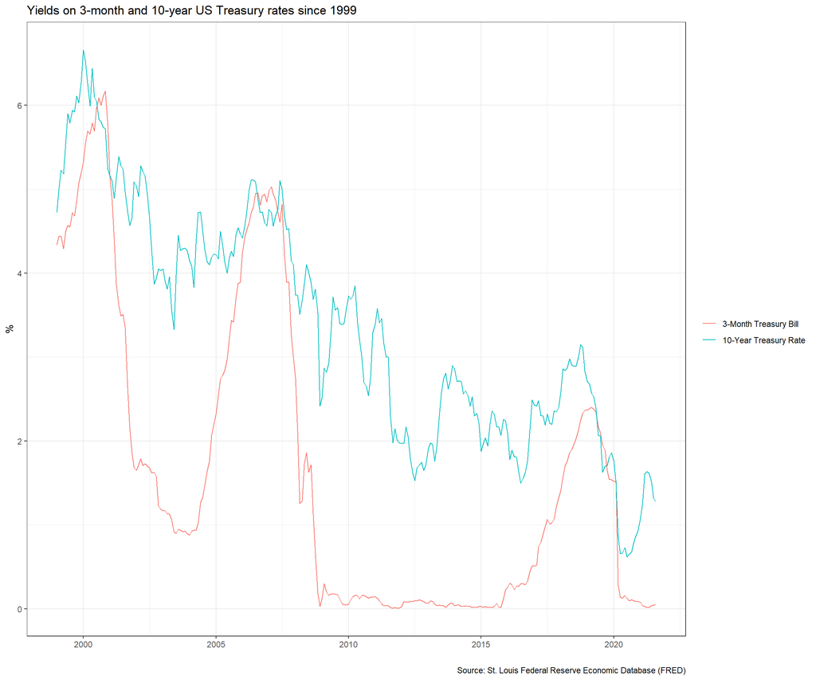

```r
yield_curve_table_4 <- yield_curve_table %>%
                       select("date", "value", "duration") %>%
                       filter( duration %in% c("3-Month Treasury Bill","10-Year Treasury Rate"))

ggplot(data = filter(yield_curve_table_4, date>= "1999-01-01"),aes(x=date, y=value, color= duration)) +
  geom_line()+
  theme_bw()+
  theme(legend.title = element_blank())+
  labs(title = "Yields on 3-month and 10-year US Treasury rates since 1999",
                 x ="",
                 y = "%",
                 caption = "Source: St. Louis Federal Reserve Economic Database (FRED)")+
  NULL
```

**Comment:**

From the more-detailed graph we can conclude that the spread widens during economic growth times and it shortens as economic conditions deteriorate or even become negative 12 to 24 months before a recession. It is worth mentioning that the spread between 10-year and 3-month T-bills has widened as positive global expectations on economic growth are increasing, especially for the US economy, as the US population receives immunity brought by vaccines.

## 1.2 Inverted yield curve graph

The code below creates a dataframe with all US recessions since 1946

```r
# get US recession dates after 1946 from Wikipedia
# https://en.wikipedia.org/wiki/List_of_recessions_in_the_United_States

recessions <- tibble(
  from = c("1948-11-01", "1953-07-01", "1957-08-01", "1960-04-01", "1969-12-01", "1973-11-01", "1980-01-01","1981-07-01", "1990-07-01", "2001-03-01", "2007-12-01","2020-02-01"),
  to = c("1949-10-01", "1954-05-01", "1958-04-01", "1961-02-01", "1970-11-01", "1975-03-01", "1980-07-01", "1982-11-01", "1991-03-01", "2001-11-01", "2009-06-01", "2020-04-30")
  )  %>%
  mutate(From = ymd(from),
         To=ymd(to),
         duration_days = To-From)


recessions
```

```
## # A tibble: 12 x 5
##    from       to         From       To         duration_days
##    <chr>      <chr>      <date>     <date>     <drtn>
##  1 1948-11-01 1949-10-01 1948-11-01 1949-10-01 334 days
##  2 1953-07-01 1954-05-01 1953-07-01 1954-05-01 304 days
##  3 1957-08-01 1958-04-01 1957-08-01 1958-04-01 243 days
##  4 1960-04-01 1961-02-01 1960-04-01 1961-02-01 306 days
##  5 1969-12-01 1970-11-01 1969-12-01 1970-11-01 335 days
##  6 1973-11-01 1975-03-01 1973-11-01 1975-03-01 485 days
##  7 1980-01-01 1980-07-01 1980-01-01 1980-07-01 182 days
##  8 1981-07-01 1982-11-01 1981-07-01 1982-11-01 488 days
##  9 1990-07-01 1991-03-01 1990-07-01 1991-03-01 243 days
## 10 2001-03-01 2001-11-01 2001-03-01 2001-11-01 245 days
## 11 2007-12-01 2009-06-01 2007-12-01 2009-06-01 548 days
## 12 2020-02-01 2020-04-30 2020-02-01 2020-04-30  89 days
```

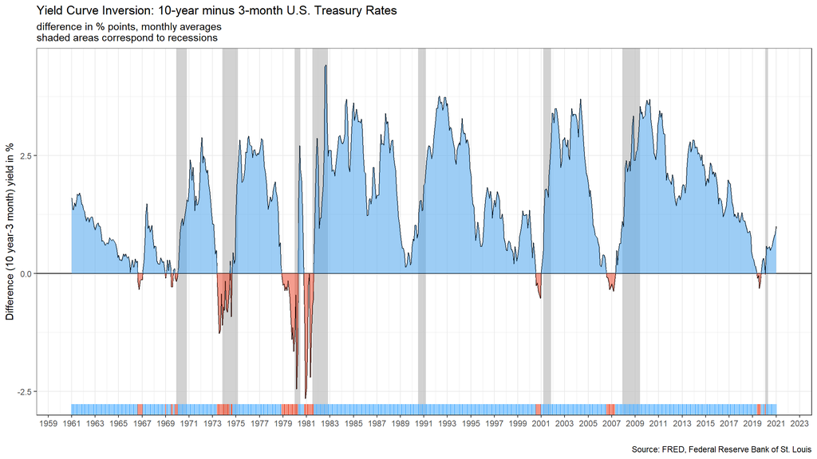

```r
library(scales)

treasury_rate_graph<- ggplot(yield_curve_table_2, aes(x = date, y= difference)) +
        geom_rect(data= filter(recessions, From > "1960-01-01"),inherit.aes = F, mapping= aes(xmin= From,xmax= To, ymin = -Inf, ymax = Inf), fill = "grey75", alpha=0.7) +
        geom_line(color= "black") +
        geom_hline(yintercept=0,color = "black") +
        geom_ribbon(aes(ymin=up,ymax=0),fill="steelblue2",alpha=0.6)  +
        geom_ribbon(aes(ymin=0,ymax=down),fill="tomato2",alpha=0.6)+
        theme_bw() +
        geom_rug(mapping = aes(color = color_id), sides= "b")+
        scale_color_manual(values = c("steelblue1","tomato2")) +
        labs(title = "Yield Curve Inversion: 10-year minus 3-month U.S. Treasury Rates",
                 subtitle = "difference in % points, monthly averages
shaded areas correspond to recessions",
                 x ="",
                 y = "Difference (10 year-3 month) yield in %",
                 caption = "Source: FRED, Federal Reserve Bank of St. Louis") +
         theme(legend.position = "none") +
         scale_x_date(date_breaks = "2 year", date_labels ="%Y", limits = c(as.Date("1961-01-01"),as.Date("2021-01-12")))+
         NULL
treasury_rate_graph
```

**Comment:**

The Yield Curve (YC) is defined as the difference (spread) between the yield on 10-year T-Bonds and yield on 3-month (or 1-year) T-Bonds. In simpler terms, YC depicts a relationship between short-term and long-term rates of most safe financial securities: Treasury Bonds. During the last 60 years, it has been interesting that mostly all times that YC inverted (negative spread), after 12-24 months, a recession began in the US (except for one occasion). The graph shows that after a period of inverted YC (red colour), a recession (shadow area) followed (except in the 1960s). Nevertheless, the inverted Yield Curve cannot predict with certainty if it would occur a recession and the depth of the recession. For instance, the 2020 Recession was caused by COVID 19 Pandemic. Nevertheless, the graph shows that there was an inverted YC before the 2020 recession. Therefore, one must be careful when concluding economic phenomena just based on a chart.